# Assignment_Pandas_Seaborn2

### Jupyter short keys

These are the most common used short keys:

- Esc + a -- Open a new cell above
- Esc + b -- Open a new cell below
- Shift + Enter -- Run the cell, and go to next one
- Ctrl + Enter -- Run the cell and stay there
- Alt + Enter -- Run the cell, and make a new one (Option-key for Mac)
- Ctrl + / -- Comment or Uncomment your selection
- Esc + m -- Change cell type into Markdown (text modus). Then run again with Crtl+Enter
- Esc + y -- Change cell type into Code (code modus). Then run again with Crtl+Enter

Let's try them out and get familiar.

# Assignment Pandas & Seaborn

## Part 1 Titanic Analysis

[figure not shown]

For this part of the assignment you will be exploring the titanic dataset and answering the following questions.

**-Make sure to create a copy of the Jupyter notebook before starting**

**-Answer all questions using seaborn plots**

## **Data Dictionary for Titanic Dataset**

Below you will find the description of each of the variables in the dataset. This is what we call as a data dictionary, You can see what each variables values refer to. Use it as a guide for your analysis.

[figure not shown]

```python
# Load the titanic dataset to google colab then run this cell
import pandas as pd
import seaborn as sns
import numpy as np
import matplotlib.pyplot as plt
sns.set(rc={'figure.figsize':(11.2,6.0)})
file_path = r"C:\Users\aiswa\Music\SC-20241013T012708Z-001\SC\data\titanic.csv"
df = pd.read_csv(file_path)

df.head(10)
```

|  | survived | pclass | sex | age | sibsp | parch | fare | embarked | class | who | adult_male | deck | embark_town | alive | alone |
| --- | --- | --- | --- | --- | --- | --- | --- | --- | --- | --- | --- | --- | --- | --- | --- |
| 0 | 0 | 3 | male | 22.0 | 1 | 0 | 7.2500 | S | Third | man | True | NaN | Southampton | no | False |
| 1 | 1 | 1 | female | 38.0 | 1 | 0 | 71.2833 | C | First | woman | False | C | Cherbourg | yes | False |
| 2 | 1 | 3 | female | 26.0 | 0 | 0 | 7.9250 | S | Third | woman | False | NaN | Southampton | yes | True |
| 3 | 1 | 1 | female | 35.0 | 1 | 0 | 53.1000 | S | First | woman | False | C | Southampton | yes | False |
| 4 | 0 | 3 | male | 35.0 | 0 | 0 | 8.0500 | S | Third | man | True | NaN | Southampton | no | True |
| 5 | 0 | 3 | male | NaN | 0 | 0 | 8.4583 | Q | Third | man | True | NaN | Queenstown | no | True |
| 6 | 0 | 1 | male | 54.0 | 0 | 0 | 51.8625 | S | First | man | True | E | Southampton | no | True |
| 7 | 0 | 3 | male | 2.0 | 3 | 1 | 21.0750 | S | Third | child | False | NaN | Southampton | no | False |
| 8 | 1 | 3 | female | 27.0 | 0 | 2 | 11.1333 | S | Third | woman | False | NaN | Southampton | yes | False |
| 9 | 1 | 2 | female | 14.0 | 1 | 0 | 30.0708 | C | Second | child | False | NaN | Cherbourg | yes | False |

### **Titanice Voyage Map**

[figure not shown]

### **Question 1: According to Wikipedia, there was an estimated 2,224 passengers and crew onboard the Titanic when it sank. How many of them do we have information for in this dataset? Of the people we have data for, how many of them survived and how many did not? What is the overall survival rate**

**Hint** Try using Countplot or Barplot in SNS

**How to Test Your Code** Load the dataset. :

- Check the total number of unique passengers.
- Check the proportion of survivors vs non survivors.
- Get the pecentage for both categories
- Plot the survivors vs non suvivors using seaborn.

```python
df.sample(10)
```

|  | survived | pclass | sex | age | sibsp | parch | fare | embarked | class | who | adult_male | deck | embark_town | alive | alone |
| --- | --- | --- | --- | --- | --- | --- | --- | --- | --- | --- | --- | --- | --- | --- | --- |
| 156 | 1 | 3 | female | 16.0 | 0 | 0 | 7.7333 | Q | Third | woman | False | NaN | Queenstown | yes | True |
| 824 | 0 | 3 | male | 2.0 | 4 | 1 | 39.6875 | S | Third | child | False | NaN | Southampton | no | False |
| 20 | 0 | 2 | male | 35.0 | 0 | 0 | 26.0000 | S | Second | man | True | NaN | Southampton | no | True |
| 127 | 1 | 3 | male | 24.0 | 0 | 0 | 7.1417 | S | Third | man | True | NaN | Southampton | yes | True |
| 727 | 1 | 3 | female | NaN | 0 | 0 | 7.7375 | Q | Third | woman | False | NaN | Queenstown | yes | True |
| 115 | 0 | 3 | male | 21.0 | 0 | 0 | 7.9250 | S | Third | man | True | NaN | Southampton | no | True |
| 166 | 1 | 1 | female | NaN | 0 | 1 | 55.0000 | S | First | woman | False | E | Southampton | yes | False |
| 823 | 1 | 3 | female | 27.0 | 0 | 1 | 12.4750 | S | Third | woman | False | E | Southampton | yes | False |
| 141 | 1 | 3 | female | 22.0 | 0 | 0 | 7.7500 | S | Third | woman | False | NaN | Southampton | yes | True |
| 129 | 0 | 3 | male | 45.0 | 0 | 0 | 6.9750 | S | Third | man | True | NaN | Southampton | no | True |

```python
sns.color_palette("rocket")
```

```python
# Write your code here
# Check the total number of unique passengers.
#df.ColumnName.unique(), there's no name
df.name.unique()
```

[output not shown]

```python
#Check the proportion of survivors vs non survivors.
a = df.groupby(['survived']).size().reset_index(name='Count')
sns.barplot(x='survived', y='Count', data=a, palette='rocket')
plt.title("Titanic Survivors", fontsize=12)
plt.xlabel("Survival Status")
plt.ylabel("Count")
plt.xticks(ticks=[0, 1], labels=["Did Not Survive", "Survived"])
plt.show()
```

[output not shown]

```
   survived  Count  Survival Status
0         0    549  Did Not Survive
1         1    342         Survived

Total passengers is 891

   survived  Count  Survival Status  Percentage
0         0    549  Did Not Survive   61.616162
1         1    342         Survived   38.383838
```

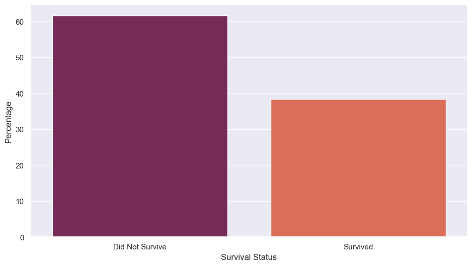

```python
#Get the pecentage for both categories

#group by and get count for survived and did not survive
a = df.groupby(['survived']).size().reset_index(name='Count')

#plot a new column to show survival status
a['Survival Status'] = a['survived'].map({0: 'Did Not Survive', 1: 'Survived'})
print (a)
print()

#get total count
total_count = df.shape[0]
print ("Total passengers is", total_count)

#percentage of survived and did not survive against total and create a new column
print()
a['Percentage'] = (a['Count'] / total_count) * 100
print (a)

#plot a bar graph for the above
sns.barplot(x='Survival Status', y='Percentage', data=a, palette='rocket')
```

```python
#Another way to do the calculation above

a = df['survived'].value_counts().reset_index()
a.columns = ['Survived', 'Count']
a['Survival Status'] = a['Survived'].map({0: 'Did Not Survive', 1: 'Survived'})
a
```

|  | Survived | Count | Survival Status |
| --- | --- | --- | --- |
| 0 | 0 | 549 | Did Not Survive |
| 1 | 1 | 342 | Survived |